# Case Study 1

DW

2022-08-24

## Case Study 1

Cyclistic provided the last 12 months of data for the following analyses (August 2021 to July 2022):

1. Determine how casual riders and annual members are using Cyclistic bikes differently
2. Design marketing strategies to convert casual riders to annual members.

Data was processed and cleaned based on the following workflow:

Libraries were loaded:

```r
library(tidyverse)
library(dplyr)
library(tidyr)
library(skimr)
library(lubridate)
library(janitor)

# Extract Past 12 Months Files and Consolidate to DB
files = list.files(path = "C://Users//dlwan//Documents//Google_Certificate//Case1//Data")
setwd("C://Users//dlwan//Documents//Google_Certificate//Case1//Data")
for (x in 1:length(files)) {
  trip_x= read_csv(files[x])
  if (x==1){
    trip = trip_x
  }
  # Check if column structure is the same in each file
  else if (compare_df_cols_same(trip,trip_x,bind_method="rbind") == TRUE){
  trip = rbind(trip,trip_x)
  }
}

# Add column for travel time (seconds)
trip=trip %>%
  mutate(ride_length = ended_at - started_at)

# Add column for day of week (Sunday = 1, Saturday = 7)
trip=trip %>%
  mutate(day_of_week = wday(started_at))

# Clean Data
# Include data with trip duration greater than 0 sec and valid day of week
# Remove rows with NA in any cell
trip2022 = trip %>%
  filter(ride_length>0) %>%
  filter(day_of_week!="") %>%
  na.omit()
```

## Summarize Parameters

Summary statistics for each member. About 42% of riders are casual. Casual riders have a longer rider time compared to annual members.

```
## # A tibble: 2 × 6
##   member_casual mean_ride_time_min mode_day mode_ride    number_of_rid…¹ perce…²
##   <chr>                      <dbl> <chr>    <chr>                  <int>   <dbl>
## 1 casual                      17.4 7        classic_bike         1949253    42.1
## 2 member                      11.5 3        classic_bike         2679704    57.9
## # … with abbreviated variable names ¹number_of_riders, ²percent_riders
```

Classic bikes were the most popular ride type. Docked bikes allowed for a longer ride time.

```
## # A tibble: 3 × 4
##   rideable_type mean_ride_time_min number_of_riders percent_riders
##   <chr>                      <dbl>            <int>          <dbl>
## 1 classic_bike                14.0          3048843           65.9
## 2 docked_bike                 24.0           224943            4.9
## 3 electric_bike               12.3          1355171           29.3
```

## Histograms

Most number of riders occur in mid-summer to early fall (June to September). Annual members consisted of the majority in off season months (October to April).

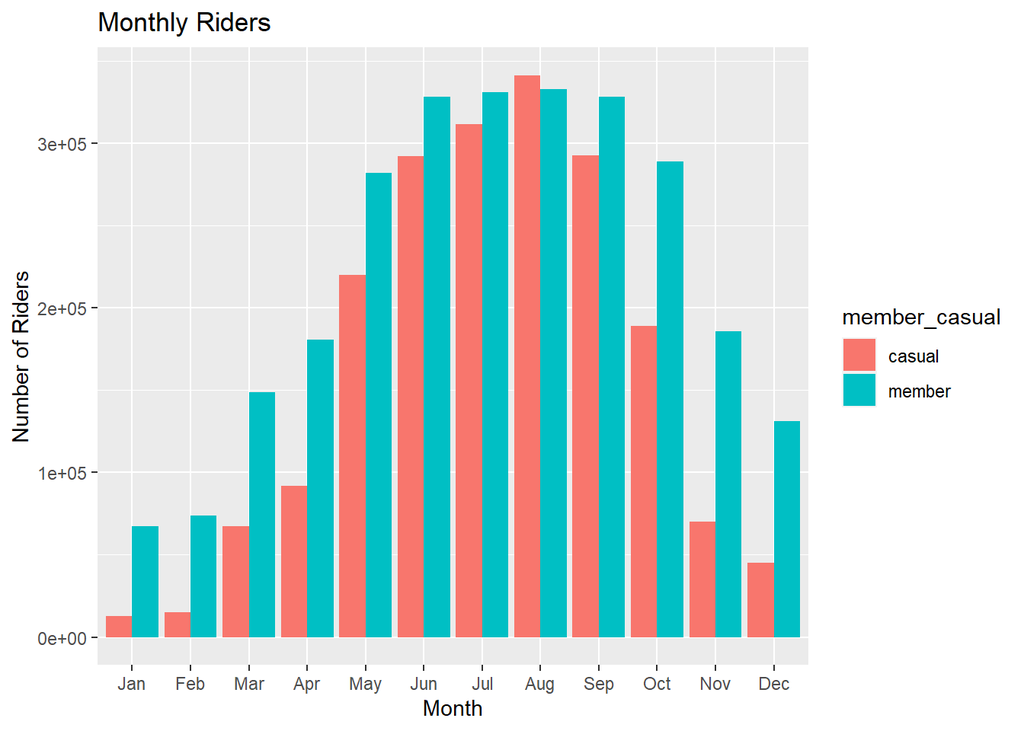

Casual riders are more active on weekends. Annual members are more active during weekdays. There is more competition for bikes on the weekends.

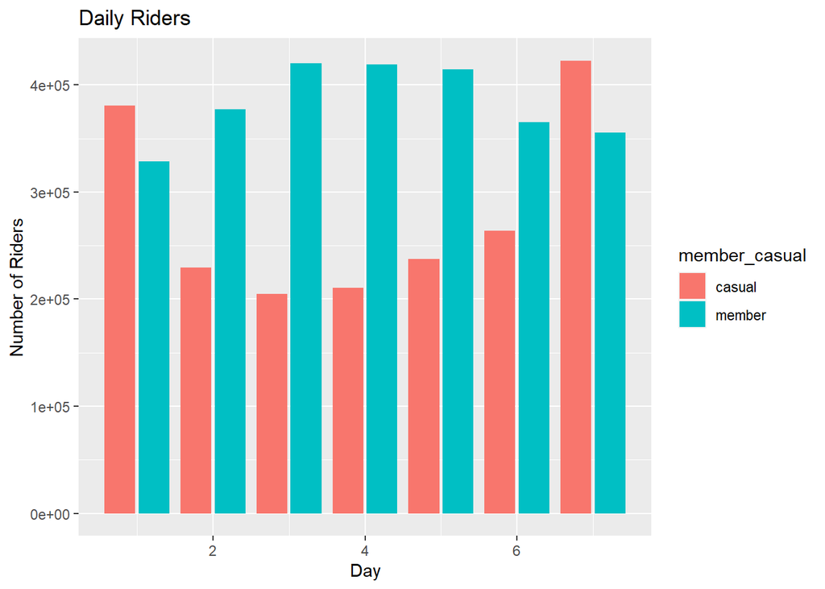

Annual members are more active during mornings and afternoon. Bikes are used for work travel purposes. Peak ride time for annual members and casual riders is between 4 and 6 PM.

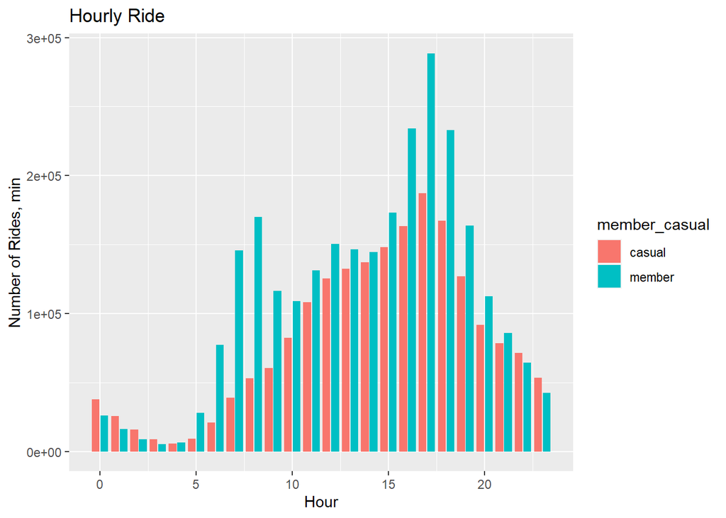

Classic bikes are preferred by both annual members and casual riders. Only casual riders use docked bikes.

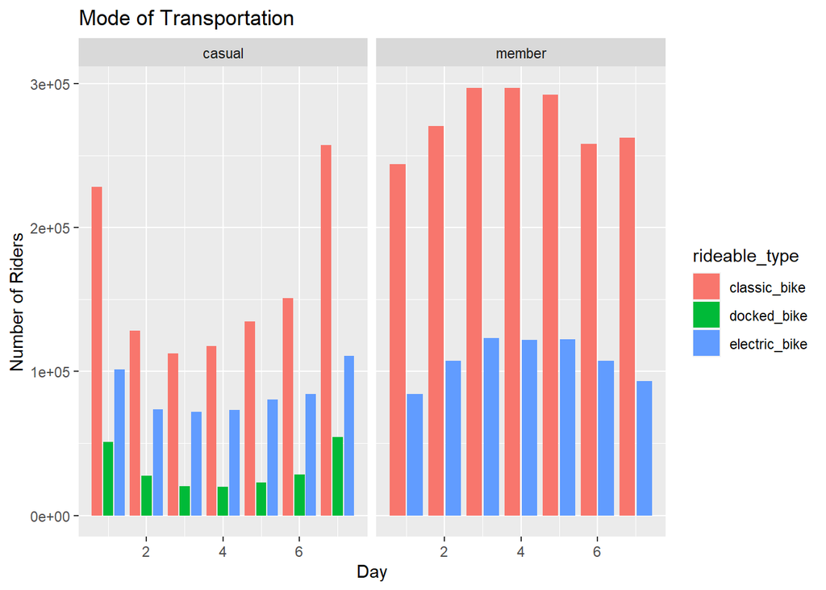

Annual members had shorter ride times compared to casual riders. Docked bikes yielded the highest average ride length.

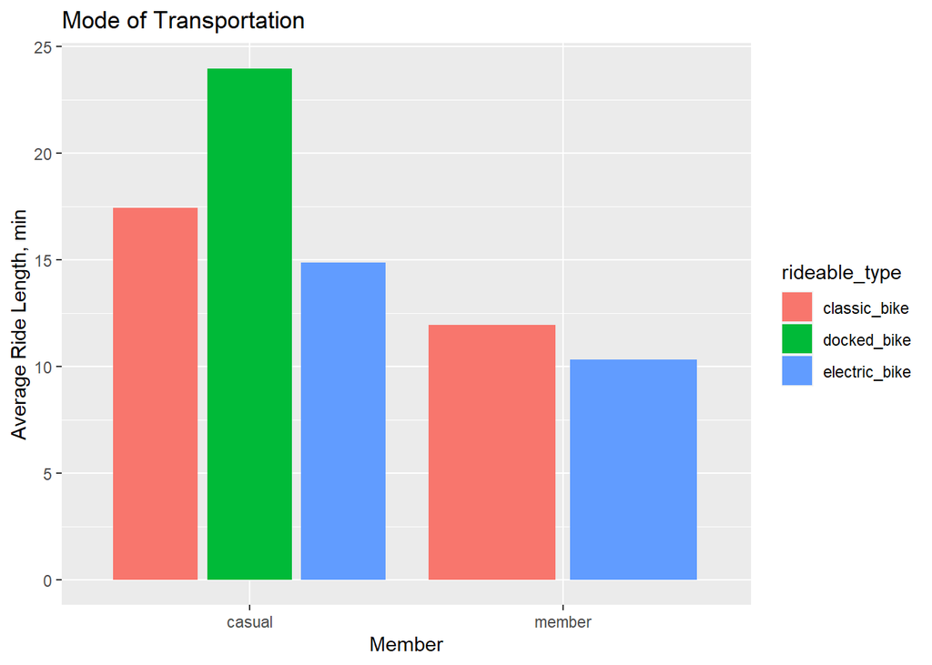

The most popular starting and ending locations for riding bikes are shown below:

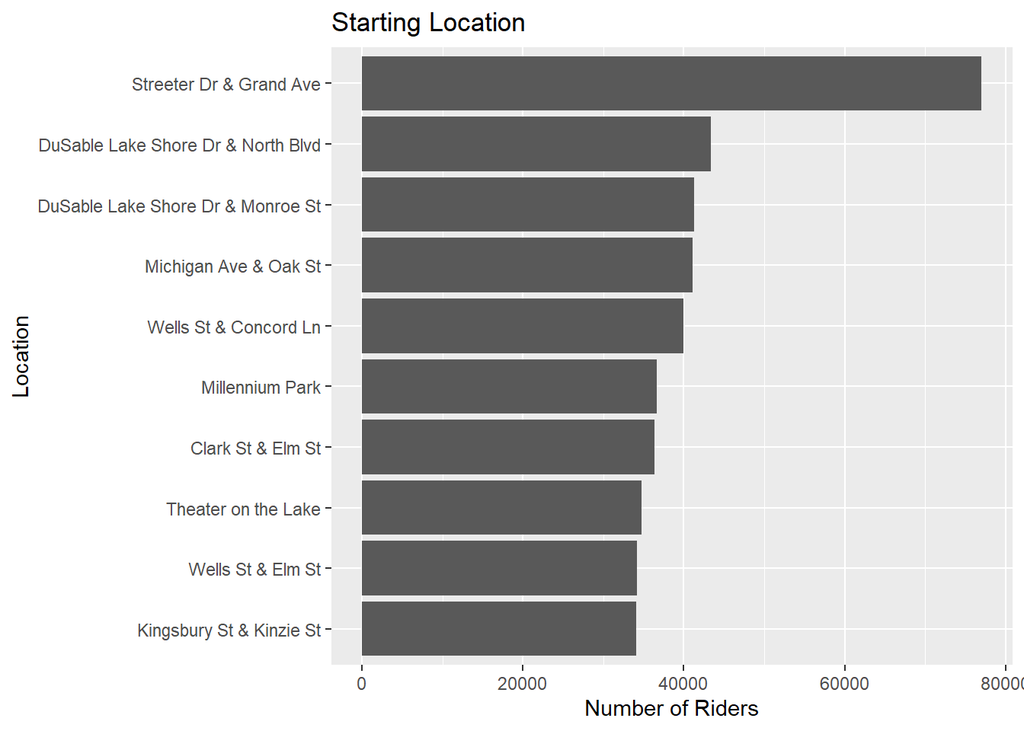

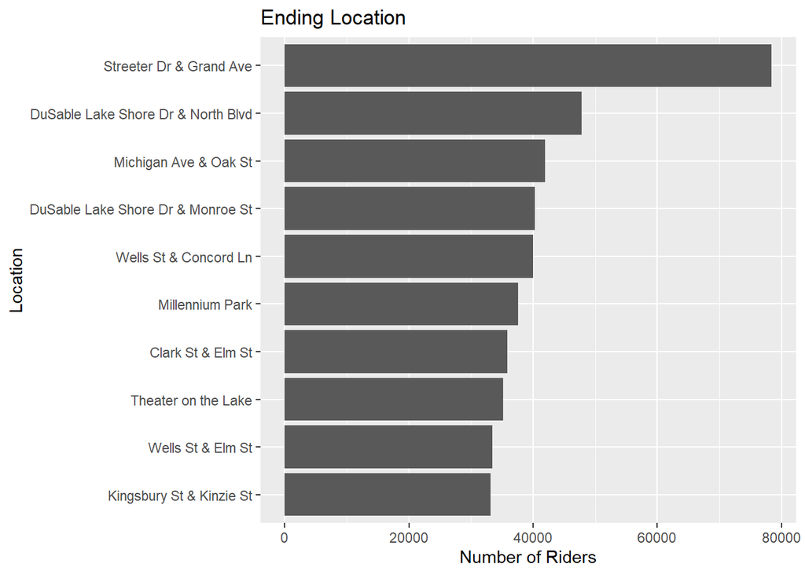

## Conclusions

Roughly 42% of rides over the past year were done by casual riders.

Casual riders:

1. Mostly active during summer months.
2. Weekends are the most popular times.
3. Docked bikes are used only by casual riders.

Annual members:

1. Use bikes as a mode of transportation to work (typically within 12 minutes).
2. Peak times are early morning and late afternoon.

## Recommendations

Over a priority program to annual members over casual riders for bikes.

1. This will appeal to casual riders who are trying to use bikes during peak times.
2. Offer additional options to docked_bikes, allowing casual members to use them more frequently.
3. Ensure the benefits of annual members is well advertised to casual riders.